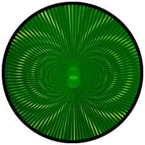

# Wellbeing and Connectedness After Ayahuasca: Findings from a Longtitudinal Pilot Study Among Retreat Participants in Petrópolis, Brazil

Authors

Affiliations

Victor Souza Eduardo

CUNY Graduate School of Public Health

Michèle Anne Barocchi, PhD, PhD

MAPS Italia

Last Updated

Jul 7, 2025

Abstract

# Methods

This pilot study administered **three questionnaires**: *Baseline*, *Follow-up*, and *One-Month*, to participants at **four ceremonial ayahuasca retreats** held at **Aldeia Akasha** in Petrópolis, Rio de Janeiro, Brazil, between January and April 2025. Each retreat included **three ayahuasca ceremonies** conducted over the course of one week.

Participants completed the **Baseline questionnaire electronically** via Qualtrics at the start of the retreat, **prior to the first ceremony**. Informed consent was obtained through an affirmative response to the consent item included at the beginning of the questionnaire. Due to the small scale and programmatic nature of the study, it did not undergo formal IRB review.

The Baseline questionnaire collected:

- **Demographic information** (e.g., age, gender, highest education level, country of origin and residence, primary language, religious affiliation, and prior spiritual/healing practices)
- **Previous ayahuasca experience**
- **Primary intention** for attending the retreat

To accommodate an **internationally diverse audience**, the education question included examples from various systems (e.g., *Ensino Fundamental*, *Lycée*, *Grundschule*), and questionnaires were offered in both **English and Portuguese**.

Participants also completed a section on **recent wellbeing over the past two weeks** (e.g., calmness, irritability, anxiety, depressive symptoms, and life satisfaction) in both the **Baseline** and **One-Month** questionnaires. A section measuring **nature and social connectedness** appeared in **all three** questionnaires.

All items used **5-point Likert scales** (e.g., from “Strongly disagree” to “Strongly agree” or “Not at all important” to “Extremely important”). Items were presented in randomized order within each section. Participants received an anonymous Participant ID for longitudinal tracking.

Immediately after the retreat, participants completed the **Follow-up questionnaire**, which repeated the **nature and social connectedness** measures and added items on:

- **Emotional and cognitive effects** (e.g., peace, connection, emotional balance, and personal insights)
- **Ceremonial elements** (e.g., presence of shamans, music, rituals, and setting)
- **Primary post-retreat emotions** (open-ended responses)

The **One-Month questionnaire** reassessed **wellbeing**, **nature and social connectedness**, and **mental health status**, using the same items as earlier questionnaires for longitudinal comparison.

All analyses and visualizations were completed using RStudio Version 2025.05.0+496 from June to July 2025.

We gratefully acknowledge the generous support of the **Guardians and support staff of Aldeia Akasha** ([link](https://uniretreats.org/akasha-retreat-center/)), without whose openness, collaboration, and hospitality this pilot study would not have been possible.

# Results

## Participant Characteristics

The *Baseline* sample of 62 participants reflects a relatively mature, well-educated, and internationally diverse group. **Most were women (58.1%)** in their early forties on average, and over half held at least a bachelor’s degree. Geographically, the largest groups came from **Brazil, the United Kingdom, and the United States**, consistent with Aldeia Akasha’s location in Rio de Janeiro, Brazil, also popular with international audiences.

**Table 1. Baseline participant characteristics by retreat**

|  | Ninawa (N=25) | Colibri Festival (N=14) | Tumã (N=4) | Nixiwaka (N=19) | Total (N=62) |
| --- | --- | --- | --- | --- | --- |
| Gender |  |  |  |  |  |
| Man | 12 (48.0%) | 4 (28.6%) | 2 (50.0%) | 8 (42.1%) | 26 (41.9%) |
| Woman | 13 (52.0%) | 10 (71.4%) | 2 (50.0%) | 11 (57.9%) | 36 (58.1%) |
| Age (years) |  |  |  |  |  |
| Mean (SD) | 40.9 (8.04) | 40.1 (9.67) | 44.5 (12.1) | 44.7 (9.24) | 42.1 (9.05) |
| Median [Min, Max] | 42.0 [24.0, 53.0] | 38.5 [28.0, 62.0] | 41.0 [35.0, 61.0] | 46.0 [26.0, 62.0] | 41.0 [24.0, 62.0] |
| Highest education level |  |  |  |  |  |
| Primary (Elementary) | 0 (0%) | 1 (7.1%) | 0 (0%) | 0 (0%) | 1 (1.6%) |
| Upper Secondary (High) | 3 (12.0%) | 3 (21.4%) | 1 (25.0%) | 3 (15.8%) | 10 (16.1%) |
| Vocational | 4 (16.0%) | 3 (21.4%) | 0 (0%) | 5 (26.3%) | 12 (19.4%) |
| Bachelor's | 11 (44.0%) | 2 (14.3%) | 0 (0%) | 6 (31.6%) | 19 (30.6%) |
| Master's | 4 (16.0%) | 4 (28.6%) | 3 (75.0%) | 5 (26.3%) | 16 (25.8%) |
| Doctoral | 3 (12.0%) | 1 (7.1%) | 0 (0%) | 0 (0%) | 4 (6.5%) |
| Times taken ayahuasca |  |  |  |  |  |
| Never | 6 (24.0%) | 3 (21.4%) | 0 (0%) | 4 (21.1%) | 13 (21.0%) |
| One time | 3 (12.0%) | 3 (21.4%) | 3 (75.0%) | 2 (10.5%) | 11 (17.7%) |
| 2–5 times | 3 (12.0%) | 2 (14.3%) | 0 (0%) | 2 (10.5%) | 7 (11.3%) |
| 6–10 times | 3 (12.0%) | 2 (14.3%) | 0 (0%) | 4 (21.1%) | 9 (14.5%) |
| More than 10 times | 10 (40.0%) | 4 (28.6%) | 1 (25.0%) | 7 (36.8%) | 22 (35.5%) |
| Ceremony intention |  |  |  |  |  |
| Spiritual growth | 11 (44.0%) | 4 (28.6%) | 3 (75.0%) | 13 (68.4%) | 31 (50.0%) |
| Mental health | 6 (24.0%) | 4 (28.6%) | 0 (0%) | 2 (10.5%) | 12 (19.4%) |
| Career | 3 (12.0%) | 4 (28.6%) | 0 (0%) | 2 (10.5%) | 9 (14.5%) |
| Other | 3 (12.0%) | 1 (7.1%) | 0 (0%) | 0 (0%) | 4 (6.5%) |
| Curiosity | 0 (0%) | 1 (7.1%) | 0 (0%) | 2 (10.5%) | 3 (4.8%) |
| Physical health | 2 (8.0%) | 0 (0%) | 1 (25.0%) | 0 (0%) | 3 (4.8%) |
| Country of residence |  |  |  |  |  |
| Brazil | 12 (48.0%) | 5 (35.7%) | 0 (0%) | 4 (21.1%) | 21 (33.9%) |
| United Kingdom | 7 (28.0%) | 2 (14.3%) | 0 (0%) | 7 (36.8%) | 16 (25.8%) |
| United States | 1 (4.0%) | 3 (21.4%) | 3 (75.0%) | 4 (21.1%) | 11 (17.7%) |
| Germany | 0 (0%) | 2 (14.3%) | 1 (25.0%) | 1 (5.3%) | 4 (6.5%) |
| Chile | 0 (0%) | 0 (0%) | 0 (0%) | 2 (10.5%) | 2 (3.2%) |
| France | 1 (4.0%) | 1 (7.1%) | 0 (0%) | 0 (0%) | 2 (3.2%) |
| Argentina | 1 (4.0%) | 0 (0%) | 0 (0%) | 0 (0%) | 1 (1.6%) |
| Ireland | 1 (4.0%) | 0 (0%) | 0 (0%) | 0 (0%) | 1 (1.6%) |
| Netherlands | 0 (0%) | 1 (7.1%) | 0 (0%) | 0 (0%) | 1 (1.6%) |
| Portugal | 1 (4.0%) | 0 (0%) | 0 (0%) | 0 (0%) | 1 (1.6%) |
| Sweden | 1 (4.0%) | 0 (0%) | 0 (0%) | 0 (0%) | 1 (1.6%) |
| United Arab Emirates | 0 (0%) | 0 (0%) | 0 (0%) | 1 (5.3%) | 1 (1.6%) |

### Questionnaire Completion

**Only 39% of participants completed all three questionnaires**, underscoring the challenges of long-term follow-up. While 62 individuals enrolled at baseline, just 24 made it to the final one-month survey. Retention varied considerably across retreats: **Tumã’s retreat had no participants complete the final questionnaire, while Ninawa’s retreat retained over half of its *Baseline* participants (52%)** through to the end.

Retention at *Follow-up* was notably higher at **73% overall**. Nixiwaka’s retreat stood out with the highest follow-up retention at 89%, likely attributable to this group’s increased contact with the research team.

**Table 2: Questionnaire completion by Retreat**

| Retreat | Baseline (*n*) | Follow-up (*n*, % retention) | 1-Mo (*n*, % retention) |
| --- | --- | --- | --- |
| Ninawa | 25 | 19 (76%) | 13 (52%) |
| Colibri Festival | 14 | 6 (43%) | 2 (14%) |
| Tumã | 4 | 3 (75%) | 0 (0%) |
| Nixiwaka | 19 | 17 (89%) | 9 (47%) |
| Total | 62 | 45 (73%) | 24 (39%) |

### Who’s Taken Ayahuasca Before?

Chart 1 shows that prior ayahuasca experience among participants was polarized at two extremes. Over a third of participants had taken ayahuasca **more than 10 times (35%)**, while the next largest group **(21%) had never taken it at all**. This bimodal distribution suggests the retreat appealed to both committed users seeking deeper work and newcomers drawn to its promise. The intermediate groups were slightly smaller (11–18%), hinting at a possible threshold beyond which individuals either commit more fully or opt out. The sample thus reflects a dynamic mix of ayahuasca-naive and highly experienced participants, with smaller proportions in between.

**Chart 1: How Many Times Have Participants Taken Ayahuasca?**

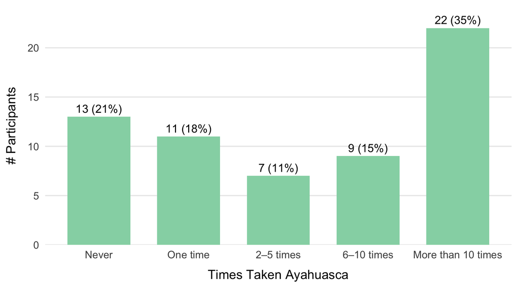

### Why Are Participants Taking Ayahuasca?

Most participants reported attending for spiritual growth (50%), followed by mental health and career motivations. However, when broken down by past ayahuasa experience, a more nuanced pattern emerged.

**Chart 2A: What are Participants’ Intentions?**

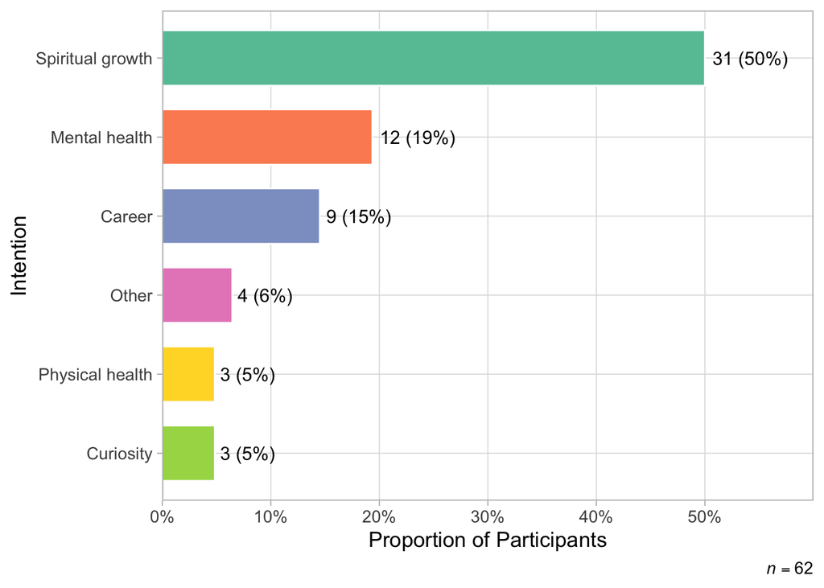

Participants’ intentions reveal a shift in orientation with increasing ayahuasca experience. **Spiritual growth** dominated among those with 6 or more previous sessions, and especially in the most experienced group, among whom 68% reported it as their main reason for attending. In contrast, participants with moderate experience (2–5 sessions) were more likely to cite **mental health** as their primary intention (57%), suggesting that early encounters with ayahuasca may be motivated by psychological growth, with spiritual growth emerging as an intention as experience deepens. Less frequent intentions such as curiosity or physical health appeared sporadically across groups, while career-related goals remained steady, possibly reflecting a distinct motivational category. Together, these patterns imply an evolving relationship to ayahuasca shaped by accumulated exposure.

**Chart 2B: Did Participants’ Intentions Change Based on Their Previous Experience?**

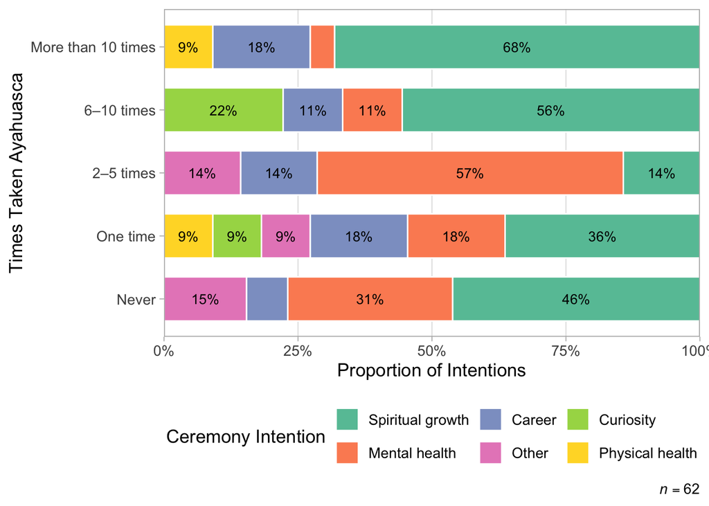

Indeed, participants who had attended 6 or more previous ceremonies (*n* = 31) were significantly more likely to report spiritual growth as their primary intention compared to those with less experience. In a logistic regression adjusting for retreat, participants in the high-experience group had more than twice the odds of reporting a spiritual intention (OR = 2.53, 95% CI: 1.16 to 5.82, *p* = 0.024*). This statistically significant association suggests that spiritual intentions may become more prominent with continued engagement in ayahuasca ceremonies, and could merit further exploration in future studies.

## Ceremonial Setting

**Chart 4: Which Aspects of the Ceremony Were Most Important to Participants?**

| Ceremonial Aspect | Mean (1 – 5) | % Very/Extremely Important |
| --- | --- | --- |
| Music | 4.91 | 97.8% |
| Physical environment | 4.65 | 95.7% |
| Shaman presence | 4.57 | 88.9% |
| Rituals & prayers | 4.54 | 95.7% |
| Group setting | 4.52 | 93.5% |
| Sharing circle | 4.04 | 76.1% |
| Immediate neighbors | 3.63 | 52.2% |

Note:  
*n* = 46, including one participant who did not finish *Baseline* but was included here for descriptive purposes

Participants were also asked to describe the ceremonial setting in one word. Common themes included feelings of *safety*, *connection*, *being held*, and a sense of *belonging*, with repeated mentions of terms like *safe*, *held*, *oneness*/*communal*. Many described the setting as *sacred*, *powerful*, and even *cosmic*, using terms such as magical, ecstasy, oneness, and celebração.

This description suggests that participants experienced the ceremonial setting as not just a physical or logistical arrangement, but also **emotionally and spiritually charged**. Participants’ language reflect that the setting fostered a profound sense of emotional security and relational trust. Simultaneously, words like *sacred*, *cosmic*, and *ecstasy* point to an **expanded or transcendent experience**, where the environment supported states of awe, unity, and transformation. Overall, participants appear to have experienced the setting not only as structured and supportive, but as a container for connection and meaning.

## Nature & Social Connectedness

Across the three questionnaires, participants reported consistently high levels of connectedness to nature. Responses to several questions showed steady increases over time, **particularly those related to social connection**. For example, average ratings for “I feel connected to others” and “I feel understood by others” rose significantly from *Baseline* to *Follow-up,* and continued increasing by *One-month*. In contrast, items like “I feel a strong spiritual bond with the Earth and its living beings” or “I feel emotionally connected to the natural world” remained high, but unchanged after the ceremonies.

Notably, the item “I feel disconnected from others” (inverted) showed a clear upward trend, indicating **reduced feelings of social disconnection following the ceremony**.

Chart 3 shows mean responses to each **Nature and Social Connectedness** item at three timepoints, where 5 = Strongly Agree, 4 = Somewhat Agree, 3 = Neither agree nor disagree, 2 = Somewhat Disagree, and 1 = Strongly Disagree.

**Chart 3: How Participants’ Nature and Social Connectedness Evolved After Retreat**

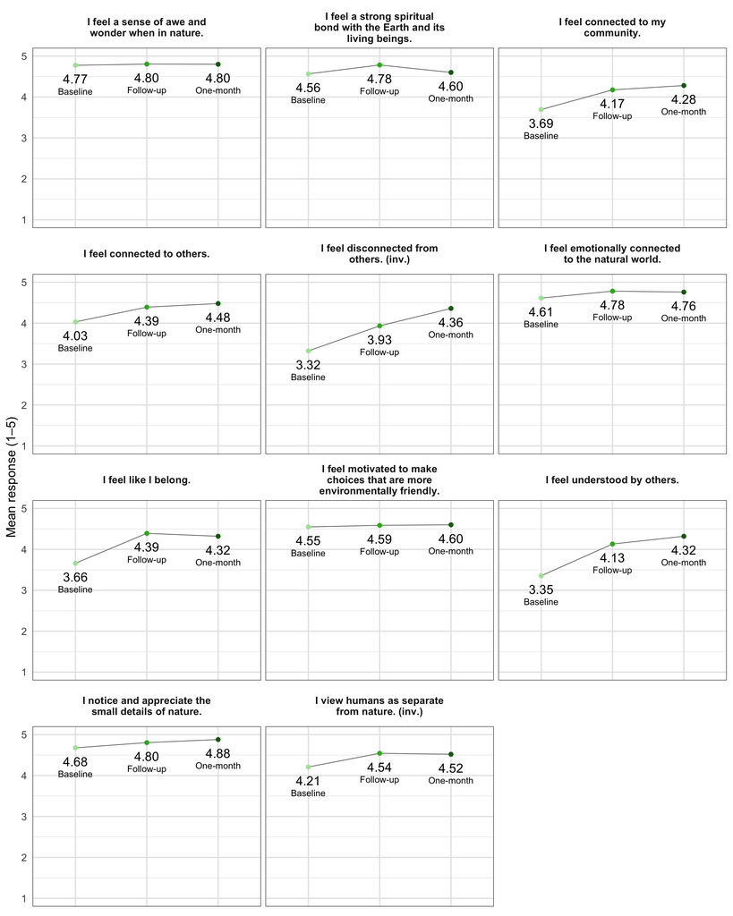

These patterns were further supported by linear mixed model results that account for longtitudinal measures, and are adjusted for participants who did not complete all three timepoints. Statistically significant improvements were found between *Baseline* and both *Follow-up* and *One-month* questionnaires for several items, especially in the **social connectedness** domain. The strongest effects were seen in **reduced social disconnection** (Estimate = –1.04, *p* < .001***) and increases in feeling understood (Estimate = –1.01, *p* < .001***). These are highly statistically significant findings, in addition to being large effect sizes (1.0, in this case, refers to a one-point improvement between, e.g., Somewhat Agree and Strongly Agree).

**Table 4: Mixed Models on Nature and Social Connectedness**

Table 4 summarizes paired comparisons between *Baseline* and both subsequent questionnaires (*Follow-up* and *One-month*) across 11 questions on Nature and Social connectedness. Linear mixed models with random intercepts were used to estimate mean differences while accounting for repeated measures and including participants who did not complete all three surveys.

Statistically significant results are color-coded: *** p < .001, (teal) ** p < .01, (green) * p < .05.

| Question | Timeline Pair | Estimate | SE | DF | p-value |
| --- | --- | --- | --- | --- | --- |
| I feel a sense of awe and wonder when in nature. | Baseline to Follow-up | -0.02 | 0.10 | 87.7 | 0.828 |
| I feel a sense of awe and wonder when in nature. | Baseline to One-month | -0.03 | 0.13 | 102.2 | 0.784 |
| I feel a strong spiritual bond with the Earth and its living beings. | Baseline to Follow-up | -0.23 | 0.12 | 87.1 | 0.068 |
| I feel a strong spiritual bond with the Earth and its living beings. | Baseline to One-month | -0.06 | 0.15 | 100.6 | 0.714 |
| I feel connected to my community. | Baseline to Follow-up | -0.47 | 0.17 | 83.4 | <.01** |
| I feel connected to my community. | Baseline to One-month | -0.60 | 0.21 | 91.0 | <.01** |
| I feel connected to others. | Baseline to Follow-up | -0.35 | 0.15 | 85.0 | 0.019* |
| I feel connected to others. | Baseline to One-month | -0.48 | 0.18 | 94.9 | 0.011* |
| I feel disconnected from others. (inv.) | Baseline to Follow-up | -0.53 | 0.20 | 84.0 | 0.010* |
| I feel disconnected from others. (inv.) | Baseline to One-month | -1.04 | 0.26 | 92.4 | <.001*** |
| I feel emotionally connected to the natural world. | Baseline to Follow-up | -0.17 | 0.12 | 87.5 | 0.163 |
| I feel emotionally connected to the natural world. | Baseline to One-month | -0.16 | 0.15 | 101.3 | 0.281 |
| I feel like I belong. | Baseline to Follow-up | -0.71 | 0.18 | 86.1 | <.001*** |
| I feel like I belong. | Baseline to One-month | -0.68 | 0.22 | 97.5 | <.01** |
| I feel motivated to make choices that are more environmentally friendly. | Baseline to Follow-up | -0.04 | 0.09 | 82.2 | 0.652 |
| I feel motivated to make choices that are more environmentally friendly. | Baseline to One-month | -0.11 | 0.12 | 88.5 | 0.343 |
| I feel understood by others. | Baseline to Follow-up | -0.79 | 0.17 | 85.9 | <.001*** |
| I feel understood by others. | Baseline to One-month | -1.01 | 0.22 | 97.1 | <.001*** |
| I notice and appreciate the small details of nature. | Baseline to Follow-up | -0.15 | 0.08 | 82.7 | 0.052 |
| I notice and appreciate the small details of nature. | Baseline to One-month | -0.28 | 0.10 | 89.6 | <.01** |
| I view humans as separate from nature. (inv.) | Baseline to Follow-up | -0.22 | 0.17 | 82.6 | 0.179 |
| I view humans as separate from nature. (inv.) | Baseline to One-month | -0.31 | 0.21 | 89.1 | 0.147 |

Note:  
Significance codes: * p < .05; ** p < .01; *** p < .001

## Recent Wellbeing

### Table 5: How Participants’ Recent Wellbeing Evolved After Retreat

Mean response on each **Recent Wellbeing** section at two timepoints, where 5 = Strongly Agree and 1 = Strongly Disagree. Note that recent wellbeing Questions were not asked at *Follow-up*, only at *Baseline* and *One-month*.

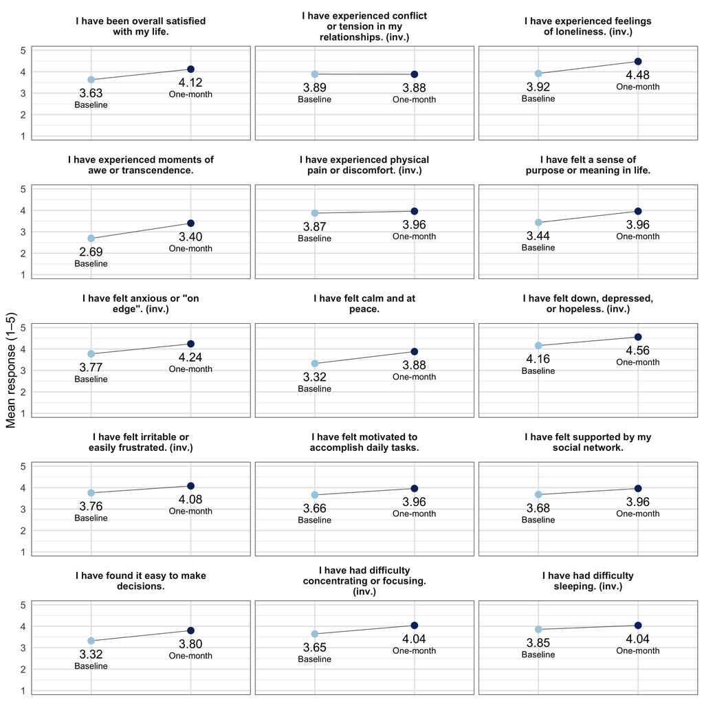

### Table 6: Mixed Models on Recent Wellbeing

Participants showed **broad and statistically significant** improvements across emotional, existential, and cognitive domains from baseline to one month following the retreat. As shown in *Table 6*, participants reported **reduced symptoms of psychological distress**, including **loneliness** (β = -0.59, p < .001***) and anxiety (β = -0.49, p < .01**), depression (β = -0.44, p < .01**), difficulty concentrating (β = -0.41, p < .01**), and irritability (β = -0.37, p = .032*). These estimates (β) represent decreases of roughly one-third to over half a scale point on the 5-point Likert scale used, corresponding to **moderate to large effect sizes.**

Positive shifts were also observed in life satisfaction (β = -0.49, p = .013*), calmness and peace (β = -0.61, p < .01**), and ease making decisions (β = -0.50, p = .023*). Participants also reported **more frequent experiences of awe or transcendence** (β = -0.80, p < .001***), a change close to a full scale point, suggesting a particularly strong impact in this domain.

Other outcomes including sense of purpose, physical discomfort, sleep quality, and perceived social support trended in a positive direction, but did not reach statistical significance. No change was observed in relationship conflict. Taken together, these results suggest a broad and meaningful **improvement in psychological wellbeing, emotional regulation, and existential engagement** one month after the retreat.

| Question | Timeline Pair | Estimate | SE | DF | p-value |
| --- | --- | --- | --- | --- | --- |
| I have been overall satisfied with my life. | Baseline to One-month | -0.49 | 0.19 | 42.3 | 0.013* |
| I have experienced conflict or tension in my relationships. (inv.) | Baseline to One-month | -0.01 | 0.13 | 44.3 | 0.967 |
| I have experienced feelings of loneliness. (inv.) | Baseline to One-month | -0.59 | 0.15 | 36.1 | <.001*** |
| I have experienced moments of awe or transcendence. | Baseline to One-month | -0.80 | 0.20 | 35.4 | <.001*** |
| I have experienced physical pain or discomfort. (inv.) | Baseline to One-month | -0.15 | 0.21 | 43.5 | 0.492 |
| I have felt a sense of purpose or meaning in life. | Baseline to One-month | -0.48 | 0.24 | 39.5 | 0.053 |
| I have felt anxious or "on edge". (inv.) | Baseline to One-month | -0.49 | 0.15 | 37.2 | <.01** |
| I have felt calm and at peace. | Baseline to One-month | -0.61 | 0.20 | 47.7 | <.01** |
| I have felt down, depressed, or hopeless. (inv.) | Baseline to One-month | -0.44 | 0.14 | 43.1 | <.01** |
| I have felt irritable or easily frustrated. (inv.) | Baseline to One-month | -0.37 | 0.16 | 40.2 | 0.032* |
| I have felt motivated to accomplish daily tasks. | Baseline to One-month | -0.40 | 0.19 | 39.7 | 0.040* |
| I have felt supported by my social network. | Baseline to One-month | -0.28 | 0.24 | 47.1 | 0.248 |
| I have found it easy to make decisions. | Baseline to One-month | -0.50 | 0.21 | 39.7 | 0.023* |
| I have had difficulty concentrating or focusing. (inv.) | Baseline to One-month | -0.41 | 0.13 | 31.0 | <.01** |
| I have had difficulty sleeping. (inv.) | Baseline to One-month | -0.24 | 0.14 | 30.7 | 0.112 |

Note:  
Significance codes: * p < .05; ** p < .01; *** p < .001

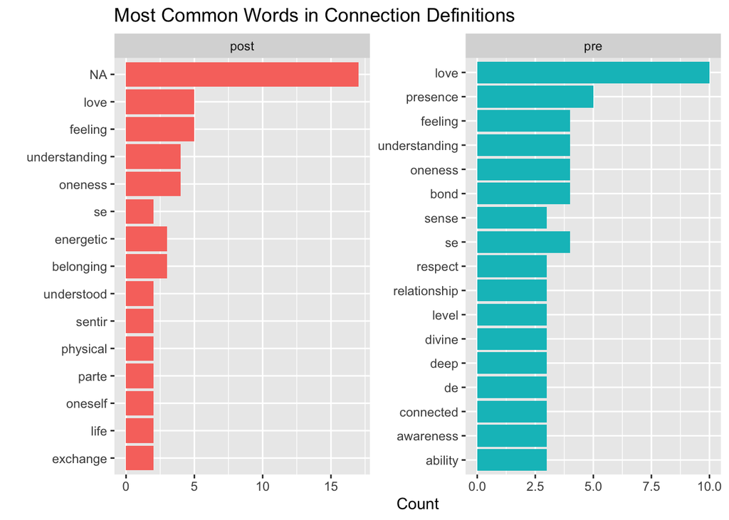

```r
nrc <- get_sentiments("nrc")

# Combine definitions
conn_defs <- baseline %>%
  select(pid, bl_conn_def) %>%
  rename(pre = bl_conn_def) %>%
  left_join(select(fu, pid, fu_conn_def_txt), by = "pid") %>%
  rename(post = fu_conn_def_txt)

# Clean and tokenize
conn_defs_tokens <- conn_defs %>%
  pivot_longer(cols = c(pre, post), names_to = "timepoint", values_to = "text") %>%
  unnest_tokens(word, text) %>%
  anti_join(stop_words, by = "word")

conn_defs_tokens %>%
  count(timepoint, word, sort = TRUE) %>%
  group_by(timepoint) %>%
  slice_max(n, n = 10) %>%
  ggplot(aes(x = reorder(word, n), y = n, fill = timepoint)) +
  geom_col(show.legend = FALSE) +
  facet_wrap(~timepoint, scales = "free") +
  coord_flip() +
  labs(title = "Most Common Words in Connection Definitions", x = "", y = "Count")
```

```r
conn_defs_tokens %>%
  inner_join(get_sentiments("nrc")) %>%
  count(timepoint, sentiment, sort = TRUE)
```

```
# A tibble: 20 × 3
   timepoint sentiment        n
   <chr>     <chr>        <int>
 1 pre       positive        63
 2 post      positive        37
 3 pre       trust           27
 4 pre       joy             25
 5 post      trust           18
 6 post      joy             14
 7 pre       anticipation    12
 8 pre       negative         9
 9 post      fear             8
10 pre       fear             8
11 post      anticipation     7
12 pre       anger            7
13 pre       sadness          7
14 post      negative         6
15 pre       surprise         6
16 post      anger            5
17 post      disgust          5
18 post      sadness          5
19 post      surprise         5
20 pre       disgust          5
```

```r
sentiment_by_pid <- conn_defs_tokens %>%
  inner_join(nrc, by = "word") %>%
  count(pid, timepoint, sentiment) %>%
  pivot_wider(names_from = timepoint, values_from = n, values_fill = 0) %>%
  mutate(diff = post - pre)
conn_defs_tokens %>%
  inner_join(nrc, by = "word") %>%
  count(timepoint, sentiment, sort = TRUE) %>%
  group_by(timepoint) %>%
  mutate(pct = n / sum(n)) %>%
  ungroup()
```

```
# A tibble: 20 × 4
   timepoint sentiment        n    pct
   <chr>     <chr>        <int>  <dbl>
 1 pre       positive        63 0.373
 2 post      positive        37 0.336
 3 pre       trust           27 0.160
 4 pre       joy             25 0.148
 5 post      trust           18 0.164
 6 post      joy             14 0.127
 7 pre       anticipation    12 0.0710
 8 pre       negative         9 0.0533
 9 post      fear             8 0.0727
10 pre       fear             8 0.0473
11 post      anticipation     7 0.0636
12 pre       anger            7 0.0414
13 pre       sadness          7 0.0414
14 post      negative         6 0.0545
15 pre       surprise         6 0.0355
16 post      anger            5 0.0455
17 post      disgust          5 0.0455
18 post      sadness          5 0.0455
19 post      surprise         5 0.0455
20 pre       disgust          5 0.0296
```

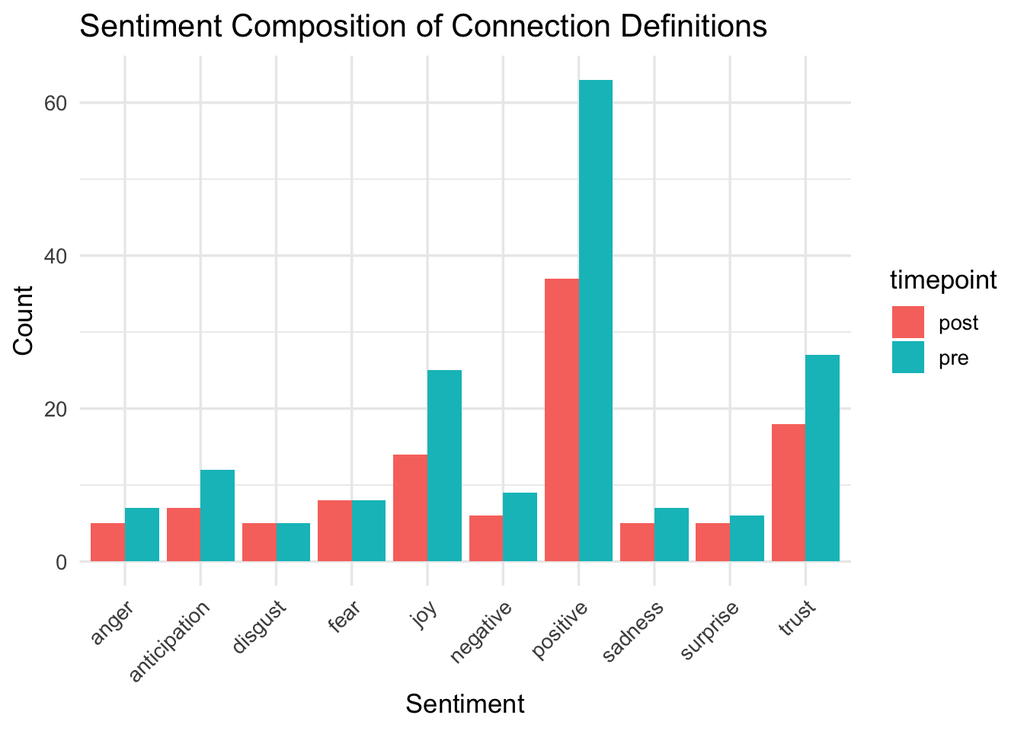

```r
conn_defs_tokens %>%
  inner_join(nrc, by = "word") %>%
  count(timepoint, sentiment) %>%
  ggplot(aes(x = sentiment, y = n, fill = timepoint)) +
  geom_col(position = "dodge") +
  labs(
    title = "Sentiment Composition of Connection Definitions",
    x = "Sentiment", y = "Count"
  ) +
  theme_minimal(base_size = 13) +
  theme(axis.text.x = element_text(angle = 45, hjust = 1))
```